# DataQuery

```python
import sqlite3
import os
import xml.etree.cElementTree as etree
import logging
import pdb
import pandas as pd
import numpy as np
import re
import matplotlib.pyplot as plt;
from bs4 import BeautifulSoup
import requests

pd.options.display.max_rows = 100
```

```python
# dump_path='/projects/ptong1/Data/SO'
# dump_database_name = 'so_dump.db'
# con = sqlite3.connect(os.path.join(dump_path, dump_database_name))
```

```python
# cursor = con.cursor()
# cursor.execute("SELECT name FROM sqlite_master WHERE type='table';")
# print(cursor.fetchall())
```

```python
conn = sqlite3.connect("so_dump_posts_tags.db")
df = pd.read_sql_query("select * from rads_posts;", conn)
df.head(5)
```

|  | ViewCount | Title | Score | OwnerDisplayName | OwnerUserId | Body | ClosedDate | Tags | LastEditorDisplayName | CommentCount | ... | AnswerCount | PostTypeId | FavoriteCount | DeletionDate | LastEditorUserId | LastActivityDate | AcceptedAnswerId | ParentID | CreationDate | Id |
| --- | --- | --- | --- | --- | --- | --- | --- | --- | --- | --- | --- | --- | --- | --- | --- | --- | --- | --- | --- | --- | --- |
| 0 | 195468.0 | What is the difference between an int and an I... | 207 | None | 25.0 | <p>I was reading <em><a href="http://rads.stac... | None | <c#><java><integer><int> | Chris Reath | 1 | ... | 22.0 | 1 | 59.0 | None | 1788806.0 | 2017-08-04T09:57:22.740 | 566.0 | NaN | 2008-08-02T21:47:34.820 | 564 |
| 1 | NaN | None | 66 | None | 198.0 | <p>In general this is a very subtle issue and ... | None | None | None | 0 | ... | NaN | 2 | NaN | None | 745188.0 | 2017-05-12T04:23:30.967 | NaN | 1276.0 | 2008-08-04T18:44:15.690 | 1490 |
| 2 | NaN | None | 45 | None | 316.0 | <p>I concur with the Dragon Book reference; IM... | None | None | None | 2 | ... | NaN | 2 | NaN | None | NaN | 2008-08-04T23:08:18.603 | NaN | 1669.0 | 2008-08-04T23:08:18.603 | 1686 |
| 3 | NaN | None | 6 | None | 316.0 | <p>I've honestly never read it myself, but <a ... | None | None | None | 0 | ... | NaN | 2 | NaN | None | NaN | 2008-08-05T15:47:15.997 | NaN | 2482.0 | 2008-08-05T15:47:15.997 | 2491 |
| 4 | NaN | None | 10 | None | 422.0 | <p><a href="http://rads.stackoverflow.com/amzn... | None | None | None | 0 | ... | NaN | 2 | NaN | None | NaN | 2008-08-05T16:16:01.150 | NaN | 1669.0 | 2008-08-05T16:16:01.150 | 2523 |

5 rows × 22 columns

```python
df.shape
```

```
(16125, 22)
```

```python
#df.Body.str.extractall('(http://rads\\.stackoverflow\\.com.*\d+)\\"')
```

```python
#df.Body.apply(lambda x: re.findall('(http://rads\\.stackoverflow\\.com/amzn/click/\d+)', x)).values
```

```python
# ISBN
df['ISBN'] = df.Body.apply(lambda x: re.findall('http://rads\\.stackoverflow\\.com/amzn/click/(\d+)', x))
```

```python
df['TagList'] = df.Tags.apply(lambda x: [ y for y in re.split('[<>]', x) if y!=''] if x is not None else ['general'])
```

```python
df.head(5)
```

|  | ViewCount | Title | Score | OwnerDisplayName | OwnerUserId | Body | ClosedDate | Tags | LastEditorDisplayName | CommentCount | ... | FavoriteCount | DeletionDate | LastEditorUserId | LastActivityDate | AcceptedAnswerId | ParentID | CreationDate | Id | ISBN | TagList |
| --- | --- | --- | --- | --- | --- | --- | --- | --- | --- | --- | --- | --- | --- | --- | --- | --- | --- | --- | --- | --- | --- |
| 0 | 195468.0 | What is the difference between an int and an I... | 207 | None | 25.0 | <p>I was reading <em><a href="http://rads.stac... | None | <c#><java><integer><int> | Chris Reath | 1 | ... | 59.0 | None | 1788806.0 | 2017-08-04T09:57:22.740 | 566.0 | NaN | 2008-08-02T21:47:34.820 | 564 | [1430209879] | [c#, java, integer, int] |
| 1 | NaN | None | 66 | None | 198.0 | <p>In general this is a very subtle issue and ... | None | None | None | 0 | ... | NaN | None | 745188.0 | 2017-05-12T04:23:30.967 | NaN | 1276.0 | 2008-08-04T18:44:15.690 | 1490 | [0596101716] | [general] |
| 2 | NaN | None | 45 | None | 316.0 | <p>I concur with the Dragon Book reference; IM... | None | None | None | 2 | ... | NaN | None | NaN | 2008-08-04T23:08:18.603 | NaN | 1669.0 | 2008-08-04T23:08:18.603 | 1686 | [1931841578] | [general] |
| 3 | NaN | None | 6 | None | 316.0 | <p>I've honestly never read it myself, but <a ... | None | None | None | 0 | ... | NaN | None | NaN | 2008-08-05T15:47:15.997 | NaN | 2482.0 | 2008-08-05T15:47:15.997 | 2491 | [0201310090] | [general] |
| 4 | NaN | None | 10 | None | 422.0 | <p><a href="http://rads.stackoverflow.com/amzn... | None | None | None | 0 | ... | NaN | None | NaN | 2008-08-05T16:16:01.150 | NaN | 1669.0 | 2008-08-05T16:16:01.150 | 2523 | [0321486811, 0201633612] | [general] |

5 rows × 24 columns

```python
df.ISBN.apply(lambda x: len(x)).value_counts()
#df.iloc[82, :].Body
```

```
1     13183
2      1456
0       876
3       394
4        92
5        52
6        29
8        10
7         9
10        6
12        5
9         4
11        3
17        2
13        2
30        1
20        1
Name: ISBN, dtype: int64
```

```python
df.TagList.apply(lambda x: len(x)).value_counts()
```

```
1    14207
3      599
2      535
4      484
5      300
Name: TagList, dtype: int64
```

## Book Mentioning Times

Below we derive a table for how many times each book is mentioned (number of posts associated with the book). It is found this is consistent with dev-books.com. For example the book 0131177052 is mentioned 306 times in our set and 309 times in the website.

This calculation is accurate. Later we have a ISBN-by-tag matrix and book mentioning from this matrix is inaccurate since same post with multiple tags will contribute multiple counting.

For by-tag counting, there is a slight difference between direct counting and from the matrix. Reason not clear at this moment.

```python
ISBN_list = df.ISBN.apply(pd.Series).stack().reset_index(drop=True)
```

```python
# this is how many times a book is associated with a post, which may associate with multiple tags
count_by_book = ISBN_list.value_counts(ascending=False)
count_by_book[count_by_book>100]
```

```
0131177052    306
0321356683    279
0201633612    273
0132350882    254
0321349601    206
0321125215    196
0596517742    178
0321127420    173
0735619670    153
0201485672    148
0596007124    139
0321545613    136
0131103628    127
0321334876    109
0321146530    103
dtype: int64
```

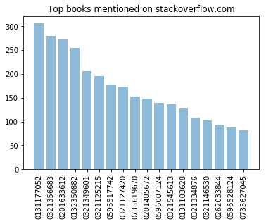

```python
ss = count_by_book[count_by_book>80]
xval = np.arange(len(ss))
yval = ss.values
plt.bar(xval, yval, align='center', alpha=0.5)
plt.xticks(xval, ss.index.values)
plt.ylabel('')
plt.xlabel('')
plt.xticks(rotation=90)
plt.title('Top books mentioned on stackoverflow.com')

plt.show()
```

## Tag Mentioning Times

To do this, we need a matrix of ISBN by Tag. Then we find top ISBN within each Tag.

```python
Tag_list = df.TagList.apply(pd.Series).stack().reset_index(drop=True)
```

```python
# this is how many times a tag is associated with a post, which may associate with multiple books
count_by_tag = Tag_list.value_counts(ascending=False)
count_by_tag[count_by_tag>10]
```

```
general                   13925
java                        252
c++                         219
c#                          171
javascript                  132
c                           125
python                      116
php                          90
algorithm                    71
design-patterns              64
.net                         61
html                         58
android                      57
amazon                       54
linux                        53
oop                          48
multithreading               46
ios                          43
ruby                         42
jquery                       41
objective-c                  41
performance                  35
assembly                     34
unit-testing                 34
domain-driven-design         34
c++11                        33
ruby-on-rails                33
web-scraping                 31
scala                        30
r                            29
css                          29
xpath                        28
amazon-web-services          27
design                       27
regex                        27
concurrency                  26
iphone                       25
asp.net-mvc                  25
osx                          24
tdd                          24
```

[output cut: 39 more lines]

```
cocoa                        13
xcode                        13
raspberry-pi                 13
memory-management            12
mongodb                      12
opencv                       12
sql-server                   12
computer-science             12
testing                      11
api                          11
gcc                          11
optimization                 11
spring                       11
rest                         11
dtype: int64
```

## Book-by-Tag Matrix

```python
min_mention = 1
```

```python
books_top = count_by_book[count_by_book>=min_mention].index
books_top
```

```
Index(['0131177052', '0321356683', '0201633612', '0132350882', '0321349601',
       '0321125215', '0596517742', '0321127420', '0735619670', '0201485672',
       ...
       '013030655', '1558606238', '0131478230', '0201066726', '0735625921',
       '0471785415', '0131550454', '1590594258', '0982337531', '0672325764'],
      dtype='object', length=5037)
```

```python
tags_top = count_by_tag[count_by_tag>=min_mention].index
'general' in tags_top.tolist()
tags_top
```

```
Index(['general', 'java', 'c++', 'c#', 'javascript', 'c', 'python', 'php',
       'algorithm', 'design-patterns',
       ...
       'java-ee-5', 'opc-ua', 'context-switch', 'qml', 'histogram', 'ppp',
       'recommendation-engine', 'resttemplate', 'mmu', 'onmouseover'],
      dtype='object', length=1993)
```

```python
print(len(books_top))
print(len(tags_top))
```

```
5037
1993
```

```python
df_book_tag = pd.DataFrame(index=books_top, columns=tags_top)
df_book_tag = df_book_tag.fillna(0)
df_book_tag.head(5)
```

|  | general | java | c++ | c# | javascript | c | python | php | algorithm | design-patterns | ... | java-ee-5 | opc-ua | context-switch | qml | histogram | ppp | recommendation-engine | resttemplate | mmu | onmouseover |
| --- | --- | --- | --- | --- | --- | --- | --- | --- | --- | --- | --- | --- | --- | --- | --- | --- | --- | --- | --- | --- | --- |
| 0131177052 | 0 | 0 | 0 | 0 | 0 | 0 | 0 | 0 | 0 | 0 | ... | 0 | 0 | 0 | 0 | 0 | 0 | 0 | 0 | 0 | 0 |
| 0321356683 | 0 | 0 | 0 | 0 | 0 | 0 | 0 | 0 | 0 | 0 | ... | 0 | 0 | 0 | 0 | 0 | 0 | 0 | 0 | 0 | 0 |
| 0201633612 | 0 | 0 | 0 | 0 | 0 | 0 | 0 | 0 | 0 | 0 | ... | 0 | 0 | 0 | 0 | 0 | 0 | 0 | 0 | 0 | 0 |
| 0132350882 | 0 | 0 | 0 | 0 | 0 | 0 | 0 | 0 | 0 | 0 | ... | 0 | 0 | 0 | 0 | 0 | 0 | 0 | 0 | 0 | 0 |
| 0321349601 | 0 | 0 | 0 | 0 | 0 | 0 | 0 | 0 | 0 | 0 | ... | 0 | 0 | 0 | 0 | 0 | 0 | 0 | 0 | 0 | 0 |

5 rows × 1993 columns

```python
df_book_tag.shape
```

```
(5037, 1993)
```

```python
def list_intersection(lst1, lst2):
    lst3 = [value for value in lst1 if value in lst2]
    return lst3
```

```python
for index, row in df.iterrows():
    book_to_update = list_intersection(books_top, row.ISBN)
    tag_to_update = list_intersection(tags_top, row.TagList)
    if len(book_to_update)>0 and len(tag_to_update)>0:
        #print(index)
        #pdb.set_trace()
        df_book_tag.loc[book_to_update, tag_to_update] = df_book_tag.loc[book_to_update, tag_to_update]+1
```

```python
df_book_tag.java.sum()
```

```
229
```

```python
df_book_tag.java.value_counts(ascending=False)
```

```
0     4895
1      115
2       15
3        6
15       1
6        1
9        1
24       1
8        1
4        1
Name: java, dtype: int64
```

```python
df_book_tag.gcc.value_counts(ascending=False)
```

```
0    5028
1       8
2       1
Name: gcc, dtype: int64
```

## Book Mentioning Times Given a Tag

To do this, we use the matrix of ISBN by Tag. Then we find top ISBN within each Tag.

[figure not shown]

```python
tag = 'c#'
mentioned = df_book_tag[tag].sort_values(ascending=False)
nShow = 20 if len(mentioned)>20 else len(mentioned)
ss = mentioned[:(nShow+1)]
xval = np.arange(len(ss))
yval = ss.values
plt.bar(xval, yval, align='center', alpha=0.5)
plt.xticks(xval, ss.index.values)
plt.ylabel('')
plt.xlabel('')
plt.xticks(rotation=90)
plt.title('Top %s books mentioned on stackoverflow.com' %(tag))

plt.show()
```

```python
tab_book_tag = df_book_tag.reset_index()
```

## Export Pandas DataFrame into sqlite3

Directly to_sql of tab_book_tag fails since it has too many columns. Since this is a sparse matrix, we extract non-zero elements and then export to sqlite;

We export the data into the production database. To save computation and load of the server, we generate views (tables) that are frequently used.

- tab_book_tag_long: for each ISBN and tag, how many posts mentioned both
- tab_book: for each ISBN, how many posts mentioning it. This will give us overall top recommended books.
- tab_tag: for each tag, how many posts mentioning it. This will give us top recommended posts.

```python
conn_production = sqlite3.connect('/projects/ptong1/Data/SO/so_production.db')
```

```python
tab_book_tag.head(3)
#tab_book_tag.iloc[1:10, :10]#.to_sql("tab_book_tag", conn, if_exists="replace")
tab_book_tag_long0 = tab_book_tag.melt(id_vars=['index'], value_vars=df_book_tag.columns.tolist())
```

```python
tab_book_tag_long0.columns = ['ISBN', 'tag', 'mentioned']
tab_book_tag_long0.head(3)
```

|  | ISBN | tag | mentioned |
| --- | --- | --- | --- |
| 0 | 0131177052 | general | 290 |
| 1 | 0321356683 | general | 257 |
| 2 | 0201633612 | general | 255 |

```python
tab_book_tag_long = tab_book_tag_long0[tab_book_tag_long0.mentioned>0]
```

```python
tab_book_tag_long.head(5)#.sort_values(by=['variable', 'value'], ascending=[True, False])
```

|  | ISBN | tag | mentioned |
| --- | --- | --- | --- |
| 0 | 0131177052 | general | 290 |
| 1 | 0321356683 | general | 257 |
| 2 | 0201633612 | general | 255 |
| 3 | 0132350882 | general | 228 |
| 4 | 0321349601 | general | 179 |

```python
tab_book_tag_long.to_sql("tab_book_tag_long", conn_production, if_exists="replace")
```

```python
# overall book mentioning; inaccurate from the book_tag matrix
#tab_book_tag_long.groupby(['ISBN']).mentioned.sum().sort_values(ascending=False)
tab_by_book = count_by_book.reset_index()
tab_by_book.columns = ['ISBN', 'mentioned']
tab_by_book.to_sql("tab_by_book", conn_production, if_exists="replace")
tab_by_book.head(3)
```

|  | ISBN | mentioned |
| --- | --- | --- |
| 0 | 0131177052 | 306 |
| 1 | 0321356683 | 279 |
| 2 | 0201633612 | 273 |

```python
tab_by_tag = tab_book_tag_long.groupby(['tag']).mentioned.sum().sort_values(ascending=False)
tab_by_tag = tab_by_tag.reset_index()
tab_by_tag.to_sql("tab_by_tag", conn_production, if_exists="replace")
tab_by_tag.head(3)
```

|  | tag | mentioned |
| --- | --- | --- |
| 0 | general | 16243 |
| 1 | java | 229 |
| 2 | c++ | 222 |

```python
print(tab_by_book.shape)
print(tab_by_tag.shape)
```

```
(5037, 2)
(1688, 2)
```

## Book Info

Now we need to extract book information such as title, author, summary, cover image from ISBN. We mostly use the isbntools package. For cover image, we download from https://openlibrary.org/dev/docs/api/covers

It turns out the openlibrary.org book cover is slow to download and get error in 2 runs, even with browser. We have to give up. Its bulk download has too many files and huge.

Now lets try scraping amazon site.

```python
import sys
from isbntools.app import meta, desc, to_isbn13, cover
from urllib.request import urlretrieve, urlopen
```

```python
tab_by_book.tail(20)
```

|  | ISBN | mentioned |
| --- | --- | --- |
| 5017 | 1584502584 | 1 |
| 5018 | 1430209755 | 1 |
| 5019 | 0735679665 | 1 |
| 5020 | 0735712352 | 1 |
| 5021 | 0691025096 | 1 |
| 5022 | 0071497528 | 1 |
| 5023 | 157870216 | 1 |
| 5024 | 1782165061 | 1 |
| 5025 | 052156543 | 1 |
| 5026 | 0596000456 | 1 |
| 5027 | 013030655 | 1 |
| 5028 | 1558606238 | 1 |
| 5029 | 0131478230 | 1 |
| 5030 | 0201066726 | 1 |
| 5031 | 0735625921 | 1 |
| 5032 | 0471785415 | 1 |
| 5033 | 0131550454 | 1 |
| 5034 | 1590594258 | 1 |
| 5035 | 0982337531 | 1 |
| 5036 | 0672325764 | 1 |

```python
myisbn = tab_by_book.ISBN.values.tolist()[0]
print(myisbn)
bookinfo = meta(myisbn) # author, isbn13, lang, publisher, title, year
print(bookinfo)
description = desc(myisbn)
print(description[:300])
print(to_isbn13(myisbn))
print(cover(myisbn))
print(cover(to_isbn13(myisbn)))
```

```
0131177052
{'Language': 'eng', 'Year': '2005', 'Authors': ['Michael C. Feathers'], 'Publisher': 'Prentice Hall Professional Technical Reference', 'Title': 'Working Effectively With Legacy Code', 'ISBN-13': '9780131177055'}
Preface Do you remember the first program you wrote? I remember mine. It
was a little graphics program I wrote on an early PC. I started programming
later than most of my friends. Sure, I'd seen computers when I was a kid. I
remember being really impressed by a minicomputer I once saw in an office,

9780131177055
{'thumbnail': 'http://books.google.com/books/content?id=QJA3dM8Uix0C&printsec=frontcover&img=1&zoom=1&edge=curl&source=gbs_api', 'smallThumbnail': 'http://books.google.com/books/content?id=QJA3dM8Uix0C&printsec=frontcover&img=1&zoom=5&edge=curl&source=gbs_api'}
{'thumbnail': 'http://books.google.com/books/content?id=QJA3dM8Uix0C&printsec=frontcover&img=1&zoom=1&edge=curl&source=gbs_api', 'smallThumbnail': 'http://books.google.com/books/content?id=QJA3dM8Uix0C&printsec=frontcover&img=1&zoom=5&edge=curl&source=gbs_api'}
```

```python
cover_url = "http://covers.openlibrary.org/b/isbn/%s-L.jpg" % (myisbn)
cover_path = '%s.jpg' % (myisbn)
print(cover_url)
print(cover_path)
```

```
http://covers.openlibrary.org/b/isbn/0131177052-L.jpg
0131177052.jpg
```

```python
#urlretrieve(cover_url, cover_path)
#urlretrieve("http://www.gunnerkrigg.com//comics/00000001.jpg", "00000001.jpg")
### openlibrary.org: slow and blocked;
#urlretrieve("http://covers.openlibrary.org/b/isbn/0131177052-L.jpg", "0131177052-L.jpg")
#urlretrieve(cover_url, cover_path)
```

```python
# amazon: the url for book image is not fixed; need serious scraping
# it is blocked by amazo with capcha
# r  = requests.get("https://www.amazon.com/dp/0131177052")
# soup = BeautifulSoup(r.text, "html.parser")
# soup.findAll("div", {"class": "a-row a-text-center"})

#cover_url ="https://www.amazon.com/dp/0131177052"
#urlretrieve(cover_url, cover_path)
# with open('test.html','w') as f:
#     f.writelines(r.text)
```

```python
# from dev-books.com
# cover_url = "http://dev-books.com/iiimg/ol/jpeg/%s.jpeg" % (myisbn)
# cover_path = 'img/%s.jpg' % (myisbn)
# #loc, resp = urlretrieve(cover_url, cover_path)
# try:
#     response_open = urlopen(cover_url) # error may occur if not present
#     urlretrieve(cover_url, cover_path)
# except Exception as e:
#     print(e)
conn.close()
conn_production.close()
```

### Final solution

At the end, we use scrapy to crawl amazon book descriptions and it works (~2000 books obtained before served with capcha), which sould cover most books.

# Building the final table for database

```python
conn = sqlite3.connect("so_production.db")
```

```python
# create left join table in sqlite:
# create table tab_book_tag_long_wtinfo as select * from tab_book_tag_long left join book_info where tab_book_tag_long.ISBN=book_info.ISBN;
#
# conn.execute('create table tab_book_tag_long_wtinfo as select * from tab_book_tag_long left join book_info where tab_book_tag_long.ISBN=book_info.ISBN;')
```

```python
tab_master = pd.read_sql_query("select * from tab_book_tag_long_wtinfo;", conn)
```

```python
tab_master.head(3)
```

|  | index | ISBN | tag | mentioned | index:1 | ISBN:1 | Title | Authors | Year | ISBN13 | Publisher | Description | Cover |
| --- | --- | --- | --- | --- | --- | --- | --- | --- | --- | --- | --- | --- | --- |
| 0 | 0 | 0131177052 | general | 290 | 0 | 0131177052 | Working Effectively With Legacy Code | Michael C. Feathers | 2005 | 9780131177055 | Prentice Hall Professional Technical Reference | Preface Do you remember the first program you ... | nan |
| 1 | 1 | 0321356683 | general | 257 | 1 | 0321356683 | Effective Java | Joshua Bloch | 2008 | 9780321356680 | Addison-Wesley | Are you looking for a deeper understanding of ... | nan |
| 2 | 2 | 0201633612 | general | 255 | 2 | 0201633612 | Design Patterns: Elements Of Reusable Object-O... | Ralph Johnson, Erich Gamma, John Vlissides, Ri... | 1995 | 9780201633610 | Addison-Wesley | Capturing a wealth of experience about the des... | nan |

```python
(tab_master.Title!='nan').value_counts()
```

```
True     6033
False    3615
Name: Title, dtype: int64
```